# formal_sample

###### PS：首次加载图表可能显示较慢，需要多刷新一下，希望耐心等待，感谢！

###### PS：The page is loading, hope to wait patiently , thanks!

## 目录 Table of Contents

一.EDA

1.概览分析（Overview analysis）

2.组合分析（Portfolio analysis）

3.场景分析（Scenario analysis）

二.建模分析（Modeling analysis）

1.申请评分卡（Application score card ）

2.集成模型 （Ensemble Learning）

## 一.EDA

### 1.概览分析（Overview analysis）

**优点**：  
1)该可视化图表可以与一个时间段进行对比*自动化*产出结论，简单明了且高效。  
2)适用在具有*总结性*的可视化报告中。

**Advantages**：  
1) The visual chart can be compared with a time period *automated* output conclusion, simple and efficient.  
2) Applicable *to summary visual* report.

[interactive chart not shown]

### 2.组合分析（Portfolio analysis）

**优点**：  
1)该可视化图表可以针对某个细化需求，进行多维度可视化分析，同时根据特定需求给出变化情况。  
2)适用在具有*周期性、维度广*的可视化报告中，例如BI或者数据化运营部门产出的日、周、月报表。  
3)该可视化图表可以拖动列与指标进行对比，具有较强*易用性*。

**Advantages**：  
1) The visualization chart can be used for multi-dimensional visual analysis of a specific requirement, and give the change according to the specific requirement.  
2) Apply to *periodic, broad dimensional* visual reports, such as Bi or daily, weekly, and monthly reports on the output of the data operations department.  
3) The visual chart is easy to use because you can *drag columns* to compare with metrics.

[interactive chart not shown]

### 3.场景分析（Scenario analysis）

**优点**：  
1)该可视化图表适合*定制化*需求，适合度多组合、重复性可视化场景。  
2)满足*快速迭代*的要求且不占用开发资源，后期形成固定化需求再开发上线。

**Advantages**：  
1) The visual chart is suitable for *customized* requirements, fit for multi-combination, repeatable visual scene.  
2) Meet the requirements of *rapid change* and do not occupy the development resources.

[interactive chart not shown]

## 二.建模分析（Modeling analysis）

### 1.申请评分卡（Application score card ）

**要点**：  
1)根据申请信息进行申请评分卡搭建，综合运用可视化图表进行展示  
2)主要展示了分箱后的*变量分布、模型情况和评分卡得分明细*等几个重要部分

**Main points**：  
1) Build the application score card according to the application information, and display it comprehensively with visual chart.  
2) Mainly show the distribution of variables after the binning, the situation of the model and the score card details, and so on.

**评分卡模型变量分布情况**：  
**Scorecard model variable distribution:**：

[interactive chart not shown]

**评分卡模型信息**：  
**Score card model information**：

###### PS：模型运用好坏比，Odds和WOE呈相反趋势模型系数为负值，WOE与业务情况成正比有利于解释模型

| Model: | Logit | Pseudo R-squared: | 0.112 |
| --- | --- | --- | --- |
| Dependent Variable: | y | AIC: | 10836.0296 |
| Date: | 2018-12-18 12:32 | BIC: | 10921.4721 |
| No. Observations: | 17457 | Log-Likelihood: | -5407.0 |
| Df Model: | 10 | LL-Null: | -6086.1 |
| Df Residuals: | 17446 | LLR p-value: | 1.0693e-285 |
| Converged: | 1.0000 | Scale: | 1.0000 |
| No. Iterations: | 7.0000 |  |  |

|  | Coef. | Std.Err. | z | P>\|z\| | [0.025 | 0.975] |
| --- | --- | --- | --- | --- | --- | --- |
| zip_code_br_encoding_Bin_WOE | -0.9506 | 0.0422 | -22.5321 | 0.0000 | -1.0332 | -0.8679 |
| int_rate_clean_Bin_WOE | -0.8508 | 0.0558 | -15.2406 | 0.0000 | -0.9602 | -0.7414 |
| purpose_br_encoding_Bin_WOE | -0.9283 | 0.0903 | -10.2850 | 0.0000 | -1.1052 | -0.7514 |
| annual_inc_Bin_WOE | -0.7641 | 0.1054 | -7.2520 | 0.0000 | -0.9706 | -0.5576 |
| inq_last_6mths_Bin_WOE | -0.7954 | 0.1040 | -7.6491 | 0.0000 | -0.9992 | -0.5916 |
| addr_state_br_encoding_Bin_WOE | -0.2853 | 0.1139 | -2.5051 | 0.0122 | -0.5086 | -0.0621 |
| mths_since_last_record_clean_Bin_WOE | -0.7737 | 0.1400 | -5.5252 | 0.0000 | -1.0481 | -0.4992 |
| limit_income_Bin_WOE | -0.3582 | 0.1551 | -2.3090 | 0.0209 | -0.6623 | -0.0542 |
| total_acc_Bin_WOE | -0.3829 | 0.1776 | -2.1558 | 0.0311 | -0.7310 | -0.0348 |
| dti_Bin_WOE | -0.7738 | 0.1832 | -4.2227 | 0.0000 | -1.1330 | -0.4146 |
| intercept | -2.0825 | 0.0265 | -78.5187 | 0.0000 | -2.1345 | -2.0305 |

**评分卡得分明细**：  
**Score card details**：

[interactive chart not shown]

### 2.集成模型 （Ensemble Learning）

**要点**：  
1)根据申请信息利用集成模型和stacing模型进行展示  
2)主要展示了*投票（软、硬投票）和stacking*的建模结果

**Main points：**：  
1) The Ensemble model and stacing model are used to show the application information.  
2) The results of voting (soft and hard voting) and stacking modeling.

**集成模型分类结果**：  
**Ensemble model results**：

```
集成学习-硬投票结果:
             precision    recall  f1-score   support

     Normal       0.92      1.00      0.96       100
      Fraud       1.00      0.91      0.95        97

avg / total       0.96      0.95      0.95       197
```

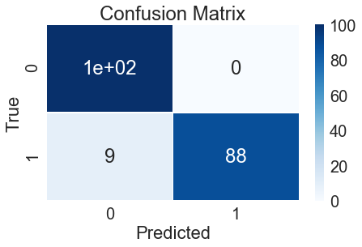

```
集成学习-软投票结果:
             precision    recall  f1-score   support

     Normal       0.93      0.96      0.95       100
      Fraud       0.96      0.93      0.94        97

avg / total       0.94      0.94      0.94       197
```

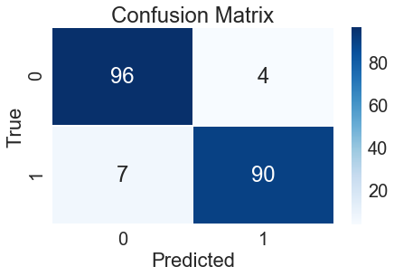

**stacking模型分类结果**：  
**Stacking model results**：

```
stacking分类结果:
             precision    recall  f1-score   support

     Normal       0.92      0.95      0.94       100
      Fraud       0.95      0.92      0.93        97

avg / total       0.93      0.93      0.93       197
```

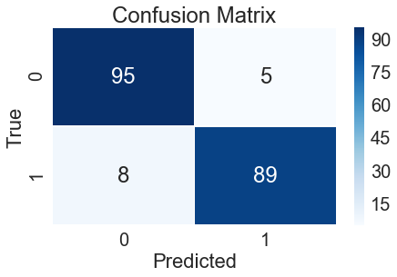

author by -- @**Liwu Dong**